# HW04 Part 1: Complete Chapter 3

26 December 2018

## Chapter 3

- Change “your name” in the YAML header above to your name.

### Section 3.1

Load the tidyverse packages. I’ve entered the first code chunk for you. **You must enter all subsequent code chunks and run the code.**

```r
library("tidyverse")
```

If you get an error, then you did not install the `tidyverse` package like you were supposed to in the previous assignment. Go back to that assignment and complete that step. (This should not be the case, though.)

### Section 3.2: First steps

Enter your code chunks for Section 3.2 here. #inserted chart of car statistics

```r
mpg
```

| manufacturer | model | displ | year | cyl | trans | drv | cty | hwy | fl | class |
| --- | --- | --- | --- | --- | --- | --- | --- | --- | --- | --- |
| audi | a4 | 1.8 | 1999 | 4 | auto(l5) | f | 18 | 29 | p | compact |
| audi | a4 | 1.8 | 1999 | 4 | manual(m5) | f | 21 | 29 | p | compact |
| audi | a4 | 2.0 | 2008 | 4 | manual(m6) | f | 20 | 31 | p | compact |
| audi | a4 | 2.0 | 2008 | 4 | auto(av) | f | 21 | 30 | p | compact |
| audi | a4 | 2.8 | 1999 | 6 | auto(l5) | f | 16 | 26 | p | compact |
| audi | a4 | 2.8 | 1999 | 6 | manual(m5) | f | 18 | 26 | p | compact |
| audi | a4 | 3.1 | 2008 | 6 | auto(av) | f | 18 | 27 | p | compact |
| audi | a4 quattro | 1.8 | 1999 | 4 | manual(m5) | 4 | 18 | 26 | p | compact |
| audi | a4 quattro | 1.8 | 1999 | 4 | auto(l5) | 4 | 16 | 25 | p | compact |
| audi | a4 quattro | 2.0 | 2008 | 4 | manual(m6) | 4 | 20 | 28 | p | compact |

[output cut: 224 more lines]

Get in the habit of entering a brief description of what each chunk of code does. Enter this above the chunk, like I did in Section 3.1.

#### Section 3.2 Questions

Answer the questions *completely.* Some answers will require you to write code in a code chunk and also to type text before or after the chunk. Other answers will require only code or only text.

**1:** Run ggplot(data = mpg). What do you see? #bigger engines use more fuel

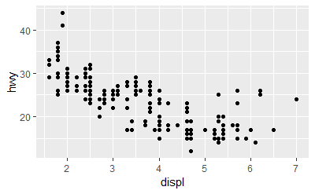

```r
ggplot(data = mpg) +
  geom_point(mapping = aes(x = displ, y = hwy))
```

**2:** How many rows are in `mpg`? How many columns? **Hint:** Use the `dim()` function. Type `dim()` in the console to learn what `dim()` does. #234 rows, 11 columns

```r
dim(mpg)
```

```
[1] 234  11
```

**3:** What does the `drv` variable describe? Read the help for `?mpg` to find out. #drv means front real drive (f) or rear wheel drive (r) or 4 wheel drive (4)

**4:** Make a scatterplot of `hwy` vs `cyl`. #this scatter plot isnt extremely useful

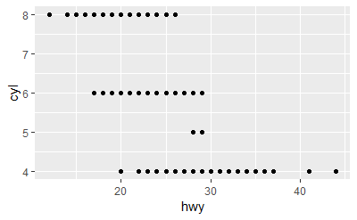

```r
ggplot(data = mpg) + geom_point(mapping = aes(x = hwy, y = cyl))
```

**5:** What happens if you make a scatterplot of `class` vs `drv`? Why is the plot not useful? #the plot is pretty evenly spread so its useless becuase theres no regular pattern to the data.

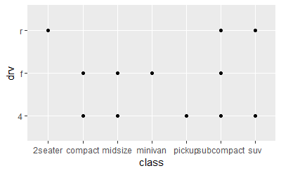

```r
ggplot(data = mpg) +
  geom_point(mapping = aes(x = class, y = drv))
```

### Section 3.3: Aesthetic mappings

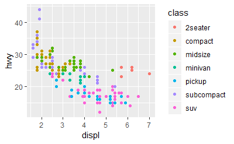

```r
ggplot(data = mpg) + geom_point(mapping = aes(x = displ, y = hwy, color = class))
```

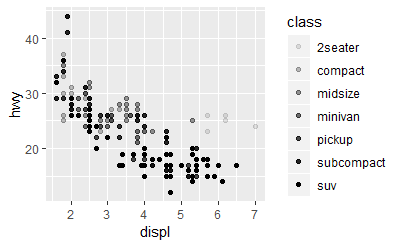

```r
# Left
ggplot(data = mpg) +
  geom_point(mapping = aes(x = displ, y = hwy, alpha = class))
```

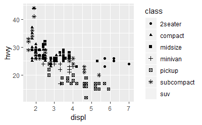

```r
# Right
ggplot(data = mpg) +
  geom_point(mapping = aes(x = displ, y = hwy, shape = class))
```

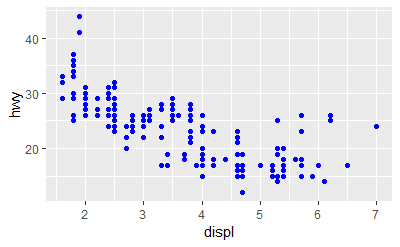

```r
ggplot(data = mpg) +
  geom_point(mapping = aes(x = displ, y = hwy), color = "blue")
```

#### Section 3.3 questions

**1:** What’s gone wrong with this code? Why are the points not blue? #The parenthesis are suppose to stop after the y value but they include the color as well. Therefore R doesnt recognise that as a color value.

**2:** Which variables in `mpg` are categorical? Which variables are continuous? (*Hint:* type `?mpg` to read the documentation for the dataset). How can you see this information when you run mpg? #The variables ‘model’, ‘cyl’, ‘year’, ‘trans’, ‘drv’, ‘fl’, and ‘class’ are categorical. ‘displ’, ‘cty’, and ‘hwy’ are continuous. When you run mpg you can see all the different categories.

**3:** Map a continuous variable to color, size, and shape. How do these aesthetics behave differently for categorical vs. continuous variables? **Note:** You need several code chunks here to answer this question. #size with continuous

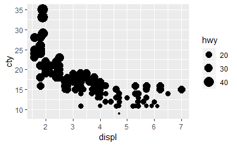

```r
ggplot(data = mpg) +
  geom_point(mapping = aes(x = displ, y = cty, size = hwy))
```

#continuous with color

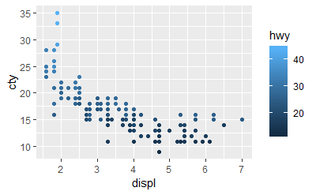

```r
ggplot(data = mpg) +
  geom_point(mapping = aes(x = displ, y = cty, color = hwy))
```

#continuous with shape

```r
ggplot(data = mpg) +
  geom_point(mapping = aes(x = displ, y = cty, shape = hwy))
```

```
Error: A continuous variable can not be mapped to shape
```

**4:** What happens if you map the same variable to multiple aesthetics? #color and size

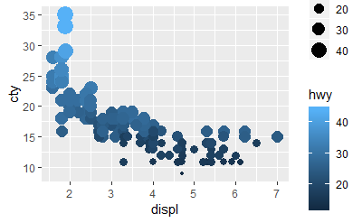

```r
ggplot(data = mpg) +
  geom_point(mapping = aes(x = displ, y = cty, color = hwy, size = hwy))
```

#you get two keys to the graph saying the same info. Every circle of a specific size is the same color. **5:** What does the stroke aesthetic do? What shapes does it work with? (*Hint:* use `?geom_point`) #Stroke changes the width of the shape border. Only works on shapes from 0-1 and 21-24.

```r
?geom_point
```

**6:** What happens if you map an aesthetic to something other than a variable name, like `aes(colour = displ < 5)`? #when you make the asthetic to something other than a variable name it creates a true/false key of the new variable.

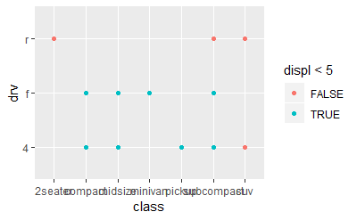

```r
ggplot(data = mpg) +
  geom_point(mapping = aes(x = class, y = drv, color = displ <5))
```

### Section 3.5: Facets

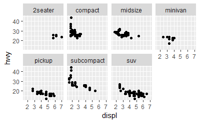

```r
ggplot(data = mpg) +
  geom_point(mapping = aes(x = displ, y = hwy)) +
  facet_wrap(~ class, nrow = 2)
```

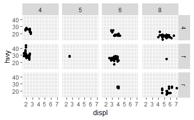

```r
ggplot(data = mpg) +
  geom_point(mapping = aes(x = displ, y = hwy)) +
  facet_grid(drv ~ cyl)
```

#### Section 3.5 questions

**1:** What happens if you facet on a continuous variable? **Note:** Write a prediction, then make and run your code chunk. #I think theres going to be an error, becuase there could be an infinite amount of facets.

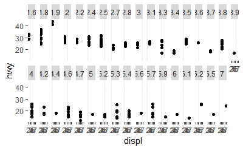

```r
ggplot(data = mpg) +
  geom_point(mapping = aes(x = displ, y = hwy)) +
  facet_wrap(~ displ, nrow = 2)
```

#There was not an error but it is very hard to read. **2:** What do the empty cells in plot with `facet_grid(drv ~ cyl)` mean? How do they relate to this plot?

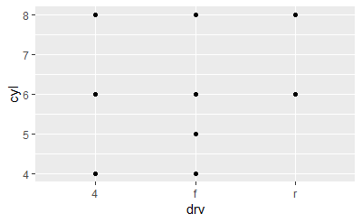

```r
ggplot(data = mpg) +
  geom_point(mapping = aes(x = drv, y = cyl))
```

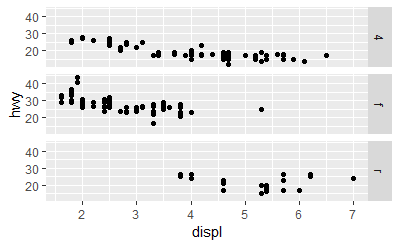

```r
ggplot(data = mpg) +
  geom_point(mapping = aes(x = displ, y = hwy)) +
  facet_grid(drv ~ .)
```

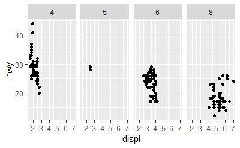

```r
ggplot(data = mpg) +
  geom_point(mapping = aes(x = displ, y = hwy)) +
  facet_grid(. ~ cyl)
```

#The . makes R make these graphs only in rows in the first graph, the second graph plots them in columns. **4:** Take the first faceted plot below. What are the advantages to using faceting instead of the colour aesthetic? What are the disadvantages? How might the balance change if you had a larger dataset?

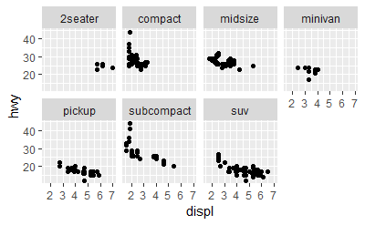

```r
ggplot(data = mpg) +
  geom_point(mapping = aes(x = displ, y = hwy)) +
  facet_wrap(~ class, nrow = 2)
```

#Facets are much easier to read than color or size asthetics. However, if there was a larger set then it would be harder to read becuase the amount of crowding.

**5:** Read `?facet_wrap`. What does `nrow` do? What does `ncol` do? What other options control the layout of the individual panels? Why doesn’t `facet_grid()` have nrow and ncol argument? `nrow` tells the program the number of rows the data goes into. `ncol` tells the program the number of columns the data goes into. Other options to control the layout of the panels are `strip.position`, `dir`, `drop`, `switch`, `as.table`, `labeller`, `shrink`, and `scales`

**6:** When using `facet_grid()` you should usually put the variable with more unique levels in the columns. Why? #This is so the data doesnt look so cluttered but more spread out. ### Section 3.6: Geometric objects

#### Section 3.6.1 Questions

**1:** What geom would you use to draw a line chart? A boxplot? A histogram? An area chart? **Note:** You will have to make some types of these charts in Part 2 of this assignment. #for a line chart you would use a line geom, for a boxplot youd use a boxplot geom, for a histogram youd use a histogram geom, for an area chart youd use an area geom.

**2:** Run this code in your head and predict what the output will look like. Then, run the code in R and check your predictions. #the x axis will have displ and y will have hwy and the color will be drv. there will also be a line through the graph.

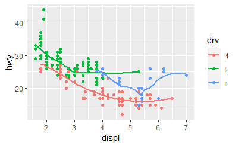

```r
ggplot(data = mpg, mapping = aes(x = displ, y = hwy, color = drv)) +
  geom_point() +
  geom_smooth(se = FALSE)
```

#the only part i was wrong about was that the lines i predicted had 3 lines rather than one that i predicted.

**3:** What does `show.legend = FALSE` do? What happens if you remove it? **Note:** Skip the “Why do you think I used it earlier in the chapter?” question. #ths removes the legend from the graph, but when you remove the command the legend reappears.

**4:** What does the `se` argument to `geom_smooth()` do? #this command asks if you want to display confidence interval around smooth, which is normally set to true as default.

1: upper left.

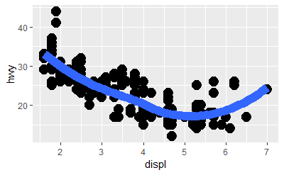

```r
ggplot(data = mpg) +
  geom_point(mapping = aes(x = displ, y = hwy, size = 3), show.legend = FALSE) +
  geom_smooth(mapping = aes(x = displ, y = hwy, size = 3), se = FALSE, show.legend = FALSE)
```

2: upper right.

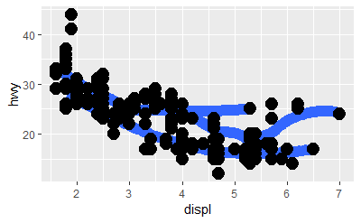

```r
ggplot(data = mpg) +
  geom_smooth(mapping = aes(x = displ, y = hwy, group = drv, size = 3), se = FALSE, show.legend = FALSE) +
  geom_point(mapping = aes(x = displ, y = hwy, size = 3), show.legend = FALSE)
```

4: middle right.

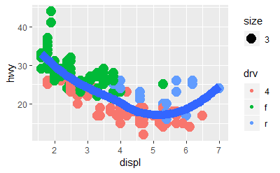

```r
ggplot(data = mpg) +
  geom_point(mapping = aes(x = displ, y = hwy, color = drv, size = 3)) +
  geom_smooth(mapping = aes(x = displ, y = hwy, size = 3), se = FALSE, show.legend = FALSE)
```

5: lower left.

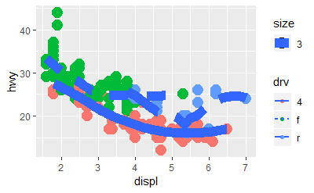

```r
ggplot(data = mpg) +
  geom_point(mapping = aes(x = displ, y = hwy, color = drv, size = 3)) +
  geom_smooth(mapping = aes(x = displ, y = hwy, group = drv, linetype = drv, size = 3), se = FALSE)
```

6: lower right. *Hint:* Read the help file for `geom_point`. Use `shape = 21`, `stroke = 2`, and `size = 3`.

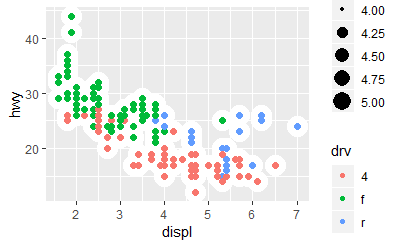

```r
ggplot(data = mpg) +
  geom_point(mapping = aes(x = displ, y = hwy, color = drv, stroke = 2, size = 5), shape = 16, color = "white") +
  geom_point(mapping = aes(x = displ, y = hwy, color = drv, stroke = 2, size = 4), shape = 16)
```

### Section 3.7: Statistical transformations.

**Skip this section.** We may return to it later.

### Section 3.8 Position adjustments

#### Section 3.8 Questions

**1:** What is the problem with this plot? How could you improve it. *Hint:* Remember the size of the `mpg` data set from earlier in this exercise. Does the number of points seem correct? **Note:** Write the code to improve it. #The plot has points that overlap each other, you could use jitter to fix this.

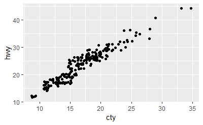

```r
ggplot(data = mpg, mapping = aes(x = cty, y = hwy)) +
  geom_point(position = "jitter")
```

**2:** What parameters to `geom_jitter()` control the amount of jittering? #width and hight

**3:** Compare and contracts `geom_jitter()` with `geom_count()`. #jitter adds a small ammount of random variation but count adds up the ammount of points per unit area then plots that ammount.

**4:** What is the default position adjustement for `geom_boxplot()`? Create a visualization of the `mpg` dataset that demonstrates it.

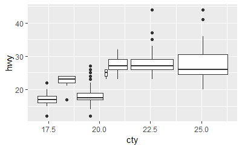

```r
ggplot(data = mpg, mapping = aes(x = cty, y = hwy)) +
  geom_boxplot(aes(group = class))
```

### Section 3.9: Coordinate systems

**Note:** Read about and do only the code chunk associated with `coord_flip()`. `coord_flip()` is a great layer to use when you have categorical data with longish names as it makes the text easier to read.

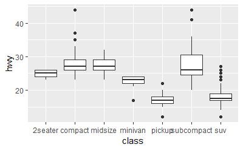

```r
ggplot(data = mpg, mapping = aes(x = class, y = hwy)) +
  geom_boxplot()
```

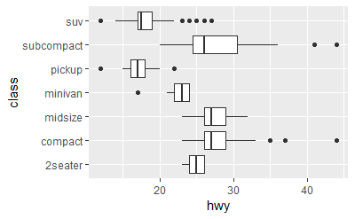

```r
ggplot(data = mpg, mapping = aes(x = class, y = hwy)) +
  geom_boxplot() +
  coord_flip()
```

### Section 3.10: The layered grammar of graphics

Just read this section as a contextual review of everything you just learned.

#PART TWO #Graph one

```r
trees
```

| Girth | Height | Volume |
| --- | --- | --- |
| 8.3 | 70 | 10.3 |
| 8.6 | 65 | 10.3 |
| 8.8 | 63 | 10.2 |
| 10.5 | 72 | 16.4 |
| 10.7 | 81 | 18.8 |
| 10.8 | 83 | 19.7 |
| 11.0 | 66 | 15.6 |
| 11.0 | 75 | 18.2 |
| 11.1 | 80 | 22.6 |
| 11.2 | 75 | 19.9 |

[output cut: 21 more lines]

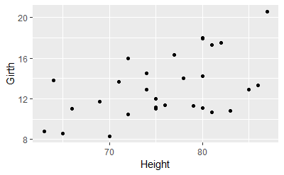

```r
ggplot(data = trees) + geom_point(mapping = aes(x = Height, y = Girth))
```

#This is no definite pattern to this chart however, it does seem that there is a positive correlation between Height and Girth.

#graph two

```r
?year
```

```r
year <- c(1821:1934)
year
```

```r
class(lynx)
as.vector(year)
```

```r
pelts <- c(as.vector(lynx))
pelts
```

```r
lynx_pelts <- data.frame(year, pelts)
lynx_pelts
```

```r
ggplot(data = lynx_pelts, mapping = aes(x = year, y = pelts)) +
  geom_line(color = "maroon")
```

[output not shown]

#graph three

```r
iris
```

| Sepal.Length | Sepal.Width | Petal.Length | Petal.Width | Species |
| --- | --- | --- | --- | --- |
| 5.1 | 3.5 | 1.4 | 0.2 | setosa |
| 4.9 | 3.0 | 1.4 | 0.2 | setosa |
| 4.7 | 3.2 | 1.3 | 0.2 | setosa |
| 4.6 | 3.1 | 1.5 | 0.2 | setosa |
| 5.0 | 3.6 | 1.4 | 0.2 | setosa |
| 5.4 | 3.9 | 1.7 | 0.4 | setosa |
| 4.6 | 3.4 | 1.4 | 0.3 | setosa |
| 5.0 | 3.4 | 1.5 | 0.2 | setosa |
| 4.4 | 2.9 | 1.4 | 0.2 | setosa |
| 4.9 | 3.1 | 1.5 | 0.1 | setosa |

[output cut: 140 more lines]

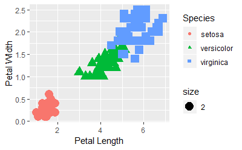

```r
ggplot(data = iris) + geom_point(mapping = aes(x = Petal.Length, y = Petal.Width, color = Species, shape = Species, size = 2)) + labs(x = "Petal Length") + labs(y = "Petal WIdth")
```

#there seems to be a clear corelation with petal length and width. The longer the petal the wider it normally is. virginica seems to be the largest petals in both length and width. setosa seems to be the smallest petals in length and width.

#graph 4 and 5

```r
geom_violin
```

[output not shown]

```r
msleep
```

| name | genus | vore | order | conservation | sleep_total | sleep_rem | sleep_cycle | awake | brainwt | bodywt |
| --- | --- | --- | --- | --- | --- | --- | --- | --- | --- | --- |
| Cheetah | Acinonyx | carni | Carnivora | lc | 12.1 | NA | NA | 11.90 | NA | 50.000 |
| Owl monkey | Aotus | omni | Primates | NA | 17.0 | 1.8 | NA | 7.00 | 0.01550 | 0.480 |
| Mountain beaver | Aplodontia | herbi | Rodentia | nt | 14.4 | 2.4 | NA | 9.60 | NA | 1.350 |
| Greater short-tailed shrew | Blarina | omni | Soricomorpha | lc | 14.9 | 2.3 | 0.1333333 | 9.10 | 0.00029 | 0.019 |
| Cow | Bos | herbi | Artiodactyla | domesticated | 4.0 | 0.7 | 0.6666667 | 20.00 | 0.42300 | 600.000 |
| Three-toed sloth | Bradypus | herbi | Pilosa | NA | 14.4 | 2.2 | 0.7666667 | 9.60 | NA | 3.850 |
| Northern fur seal | Callorhinus | carni | Carnivora | vu | 8.7 | 1.4 | 0.3833333 | 15.30 | NA | 20.490 |
| Vesper mouse | Calomys | NA | Rodentia | NA | 7.0 | NA | NA | 17.00 | NA | 0.045 |
| Dog | Canis | carni | Carnivora | domesticated | 10.1 | 2.9 | 0.3333333 | 13.90 | 0.07000 | 14.000 |
| Roe deer | Capreolus | herbi | Artiodactyla | lc | 3.0 | NA | NA | 21.00 | 0.09820 | 14.800 |

[output cut: 73 more lines]

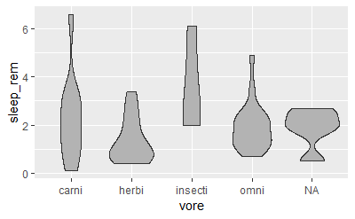

```r
ggplot(data = msleep) +
  geom_violin(mapping = aes(x = vore, y = sleep_rem), fill = "grey70")
```

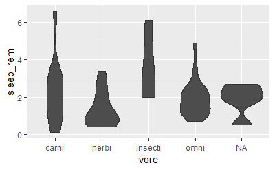

```r
ggplot(data = msleep) +
  geom_violin(mapping = aes(x = vore, y = sleep_rem), fill = "grey30")
```

#A violin plot is similar to a box plot but also show the probability density. The grey value correlates to how dark the grey is. The higher the grey value the lighter the shade.

#graph 7

```r
?msleep
```

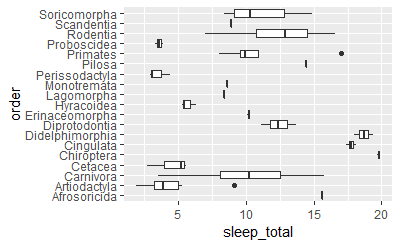

```r
ggplot(data = msleep) + geom_boxplot(mapping = aes(x = order, y = sleep_total)) + coord_flip()
```

#Some species seem to have much more variation in sleep amount than others. carnivora seems to have the most variation while there are multiple species that have very little variation.

#graph 8

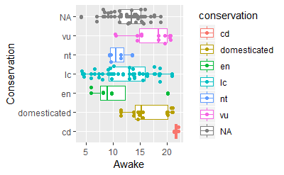

```r
data("msleep")
ggplot(data = msleep) + geom_boxplot(mapping =  aes(x = conservation, y = awake, color = conservation)) + labs(x = "Conservation") + labs (y = "Awake") + geom_jitter(mapping = aes(x = conservation, y = awake, color = conservation)) + geom_point(mapping = aes(x = conservation, y = awake, color = conservation)) + coord_flip() + scale_fill_discrete(name = "Concervation")
```

#Graph 9 and 10

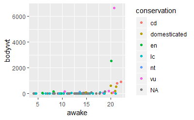

```r
ggplot(data = msleep) +
  geom_point(mapping = aes(x = awake , y = bodywt, color = conservation))
```

[figure not shown]

```r
ggplot(data = msleep) +
  geom_point(mapping = aes(x = awake , y = brainwt, color = order)) +
  facet_wrap(~ conservation, ncol = 3)
```